# nwr

Ron Pomper

2026-06-03

## Demographics

| Year | Dx | N | Age (months) | Age (min-max) | Gender |
| --- | --- | --- | --- | --- | --- |
| 7 | DLD | 38 | 86.47 | 74-96 | F: 16, M: 22 |
| 7 | TLD | 45 | 86.60 | 76-98 | F: 25, M: 20 |
| 8 | DLD | 33 | 99.00 | 87-111 | F: 14, M: 19 |
| 8 | TLD | 42 | 98.14 | 84-109 | F: 24, M: 18 |
| 9 | DLD | 32 | 110.38 | 100-121 | F: 14, M: 18 |
| 9 | TLD | 41 | 112.29 | 103-138 | F: 23, M: 18 |
| 10 | DLD | 33 | 122.18 | 112-133 | F: 14, M: 19 |
| 10 | TLD | 41 | 122.93 | 114-133 | F: 23, M: 18 |

### Data Loss

| Dx | Missing_Year | n |
| --- | --- | --- |
| DLD | 8 | 5 |
| DLD | 9 | 6 |
| DLD | 10 | 5 |
| TLD | 8 | 3 |
| TLD | 9 | 4 |
| TLD | 10 | 4 |

Reasons

stopped after year 1:

- 8
- 39
- 42
- 63
- 68
- 73
- 97
- 123

stopped after year 2:

- 44

missing only year 3

- 91

| Subject | Dx | Gender | Missing_Year |
| --- | --- | --- | --- |
| 8 | TLD | M | 8 |
| 8 | TLD | M | 9 |
| 8 | TLD | M | 10 |
| 39 | DLD | M | 8 |
| 39 | DLD | M | 9 |
| 39 | DLD | M | 10 |
| 42 | TLD | F | 8 |
| 42 | TLD | F | 9 |
| 42 | TLD | F | 10 |
| 44 | TLD | F | 9 |
| 44 | TLD | F | 10 |
| 63 | DLD | M | 8 |
| 63 | DLD | M | 9 |
| 63 | DLD | M | 10 |
| 68 | DLD | F | 8 |
| 68 | DLD | F | 9 |
| 68 | DLD | F | 10 |
| 73 | TLD | M | 8 |
| 73 | TLD | M | 9 |
| 73 | TLD | M | 10 |
| 91 | DLD | M | 9 |
| 97 | DLD | F | 8 |
| 97 | DLD | F | 9 |
| 97 | DLD | F | 10 |
| 123 | DLD | M | 8 |
| 123 | DLD | M | 9 |
| 123 | DLD | M | 10 |

## Age-related changes

### Plot

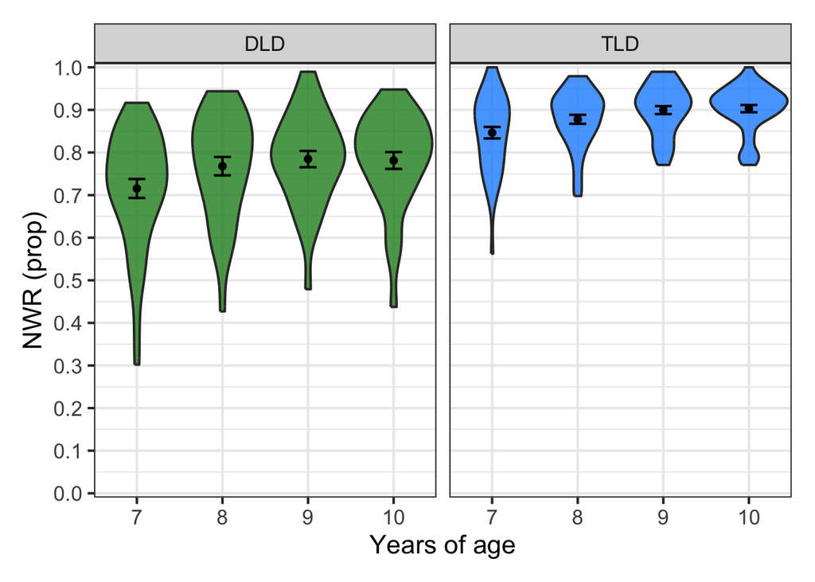

| Dx_yr1 | Year | N | NWR_prop | SD | SE |
| --- | --- | --- | --- | --- | --- |
| DLD | 7 | 38 | 0.715 | 0.137 | 0.022 |
| DLD | 8 | 33 | 0.768 | 0.124 | 0.022 |
| DLD | 9 | 32 | 0.785 | 0.108 | 0.019 |
| DLD | 10 | 33 | 0.781 | 0.114 | 0.020 |
| TLD | 7 | 45 | 0.847 | 0.091 | 0.014 |
| TLD | 8 | 42 | 0.878 | 0.068 | 0.011 |
| TLD | 9 | 41 | 0.900 | 0.060 | 0.009 |
| TLD | 10 | 41 | 0.903 | 0.055 | 0.009 |

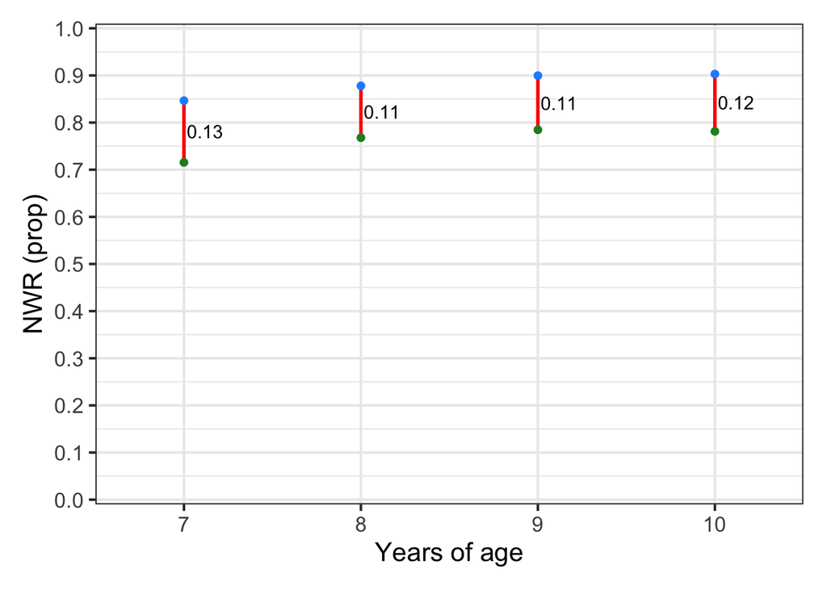

### GCA models

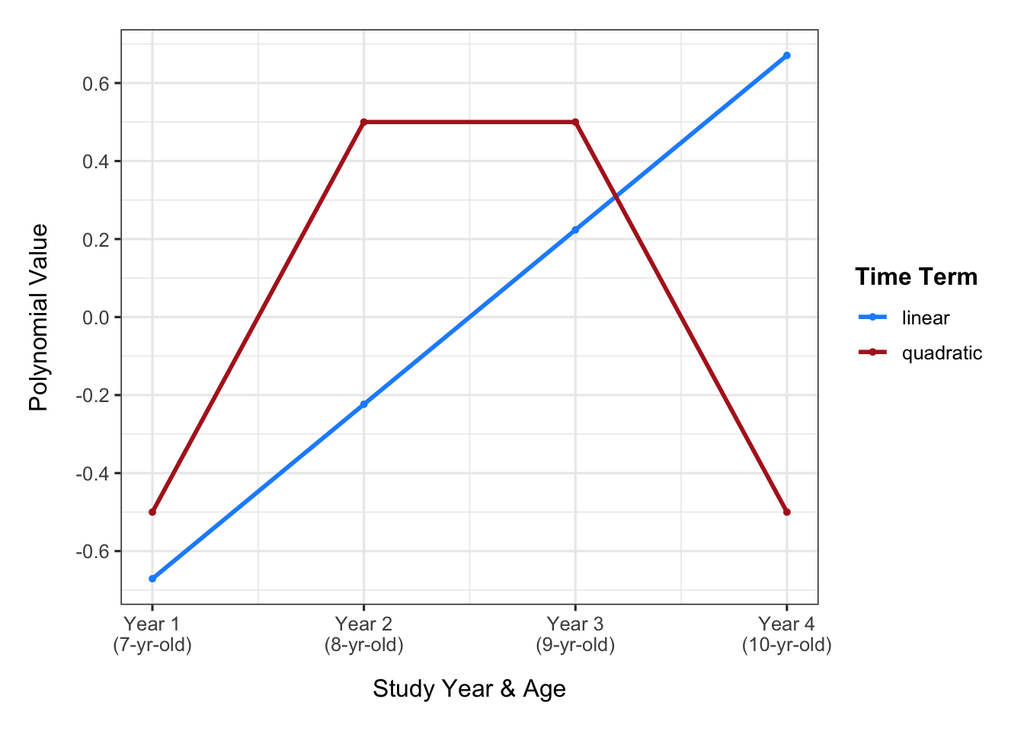

```r
m <- lmer(NWR_prop ~ (linear+quadratic)*Dx_yr1 + (linear+quadratic|Subject),data=d)

Anova(m,type=3,test='F')
```

```
## Analysis of Deviance Table (Type III Wald F tests with Kenward-Roger df)
##
## Response: NWR_prop
##                          F Df Df.res                Pr(>F)
## (Intercept)      7534.0824  1 80.789 < 0.00000000000000022 ***
## linear             37.7060  1 77.429         0.00000003290 ***
## quadratic          13.6756  1 74.003             0.0004145 ***
## Dx_yr1             37.9662  1 80.789         0.00000002667 ***
## linear:Dx_yr1       0.3477  1 77.429             0.5571247
## quadratic:Dx_yr1    1.8869  1 74.003             0.1737035
## ---
## Signif. codes:  0 '***' 0.001 '**' 0.01 '*' 0.05 '.' 0.1 ' ' 1
```

### GCA fit

Plotting the model predictions - we can see that it does a good job fitting the data:

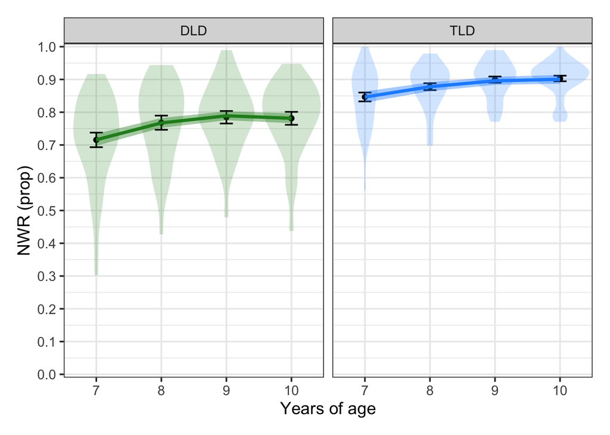

### GCA results

```
## Analysis of Deviance Table (Type III Wald F tests with Kenward-Roger df)
##
## Response: NWR_prop
##                          F Df Df.res                Pr(>F)
## (Intercept)      7534.0824  1 80.789 < 0.00000000000000022 ***
## linear             37.7060  1 77.429         0.00000003290 ***
## quadratic          13.6756  1 74.003             0.0004145 ***
## Dx_yr1             37.9662  1 80.789         0.00000002667 ***
## linear:Dx_yr1       0.3477  1 77.429             0.5571247
## quadratic:Dx_yr1    1.8869  1 74.003             0.1737035
## ---
## Signif. codes:  0 '***' 0.001 '**' 0.01 '*' 0.05 '.' 0.1 ' ' 1
```

Collapsing across groups, there was a significant effect of linear time, *b*=0.045, *F*(1,77.43)=37.71, *p* < .001. The proportion of phonemes children correctly repeated increased from year 1 (*M*=0.787, *SD*=0.131) to year 4 (*M*=0.849, *SD*=0.105).

There was also a significant effect of quadratic time, *b*=-0.021, *F*(1,74)=13.68, *p* < .001. This year-to-year increase plateaued between year 3 (*M*=0.849, *SD*=0.101) and year 4 (*M*=0.849, *SD*=0.105).

There was a significant effect of diagnostic group, *b*=0.117, *F*(1,80.79)=37.97, *p* < .001. Averaging across all 4 years, children in the DLD group (*M*=0.76, *SD*=0.124) were less accurate in NWR than children in the TLD group (*M*=0.881, *SD*=0.073).

The interaction between diagnostic group and linear time was not significant, *b*=-0.009, *F*(1,77.43)=0.35, *p* = .557. This suggests that both groups experience similar average growth each year.

The interaction between diagnostic group and quadratic time was not significant, *b*=0.016, *F*(1,74)=1.89, *p* = .174. This suggests that both groups experience a similar plateau between years 3 and 4.

### GCA subset

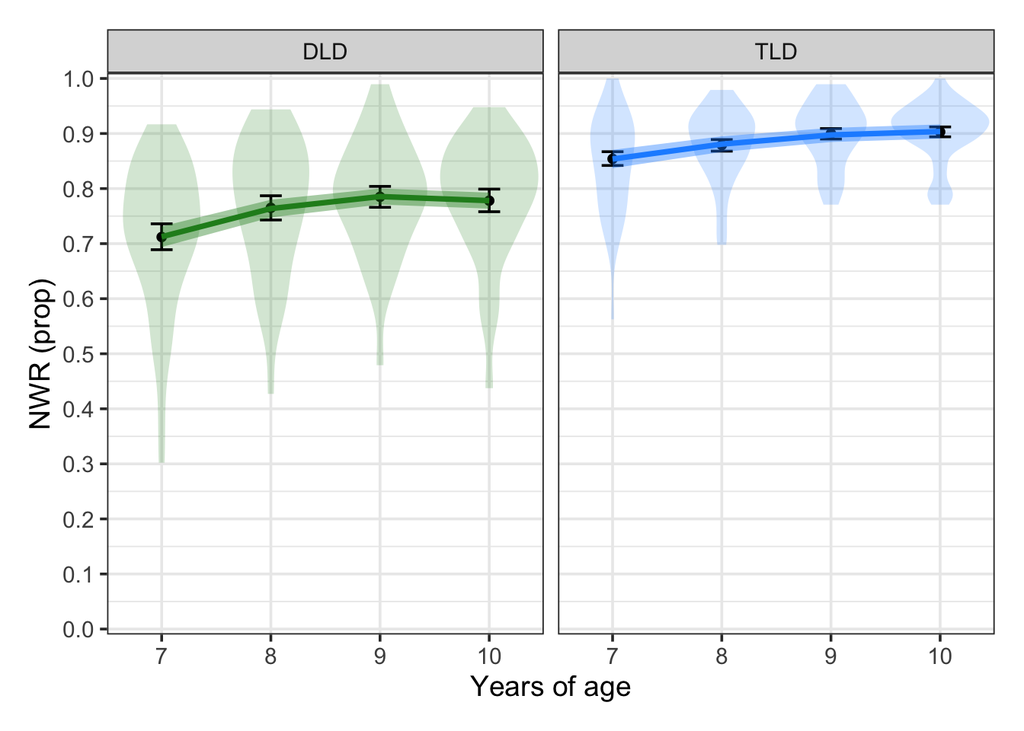

Limiting the analyses to just children with data in all 4 years, we find a similar pattern of results:

| Dx_yr1 | Year | n | NWR_prop |
| --- | --- | --- | --- |
| DLD | 7 | 32 | 0.7122396 |
| DLD | 8 | 32 | 0.7646063 |
| DLD | 9 | 32 | 0.7846351 |
| DLD | 10 | 32 | 0.7784358 |
| TLD | 7 | 41 | 0.8544207 |
| TLD | 8 | 41 | 0.8785512 |
| TLD | 9 | 41 | 0.8995957 |
| TLD | 10 | 41 | 0.9029920 |

```
##  Groups   Name        Std.Dev. Corr
##  Subject  (Intercept) 0.078636
##           linear      0.040479 -0.528
##           quadratic   0.011334  0.408  0.560
##  Residual             0.046925
```

```
## Analysis of Deviance Table (Type III Wald F tests with Kenward-Roger df)
##
## Response: NWR_prop
##                          F Df Df.res                Pr(>F)
## (Intercept)      7212.1957  1     71 < 0.00000000000000022 ***
## linear             34.7499  1     71         0.00000011555 ***
## quadratic          12.1243  1     71             0.0008558 ***
## Dx_yr1             40.9780  1     71         0.00000001441 ***
## linear:Dx_yr1       0.6293  1     71             0.4302666
## quadratic:Dx_yr1    2.7595  1     71             0.1010906
## ---
## Signif. codes:  0 '***' 0.001 '**' 0.01 '*' 0.05 '.' 0.1 ' ' 1
```

Simplifying random effects to remove the quadratic slope:

```
## Analysis of Deviance Table (Type III Wald F tests with Kenward-Roger df)
##
## Response: NWR_prop
##                          F Df Df.res                Pr(>F)
## (Intercept)      7212.3447  1     71 < 0.00000000000000022 ***
## linear             34.8603  1     71         0.00000011123 ***
## quadratic          12.4381  1    144             0.0005647 ***
## Dx_yr1             40.9788  1     71         0.00000001441 ***
## linear:Dx_yr1       0.6313  1     71             0.4295382
## quadratic:Dx_yr1    2.8309  1    144             0.0946338 .
## ---
## Signif. codes:  0 '***' 0.001 '**' 0.01 '*' 0.05 '.' 0.1 ' ' 1
```

The only difference from the full model is that the interaction between quadratic time and diagnostic group is marginally significant where it was not significant before. This needs to be interpreted with caution, however, not only because it is marginally significant, but also because the full model random effect structure yielded a singular fit and the random slope for the interaction between quadratic time and diagnostic group was removed to address this problem.

The change change to a marginal effect with the subset of participants suggests less of a plateauing effect for the TLD group.

## Cross-year comparison

Let’s focus on NWR for the DLD group in year 4 and the TLD group in year 1:

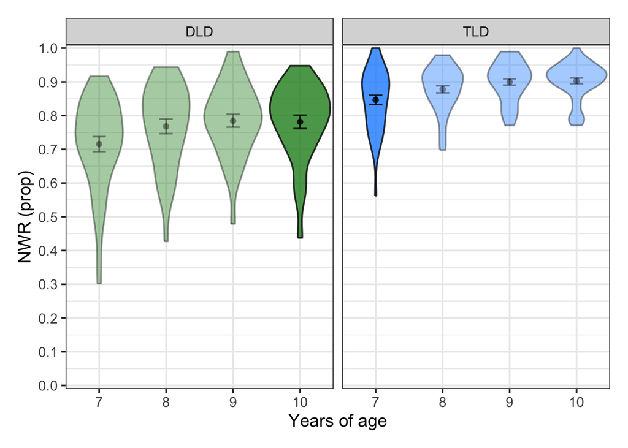

We have year 1 NWR scores for 45 children in the TLD group. We are missing NWR scores for 0 children. And we are missing vocabulary scores for 0 children.

We have year 4 NWR scores for 33 children in the DLD group. We are missing NWR scores for 5 children (68, 97, 39, 63, 123). And we are missing vocabulary scores for 7 children (68, 81, 97, 39, 63, 123, 139).

### Age

#### All

Here are the average ages for children with NWR scores:

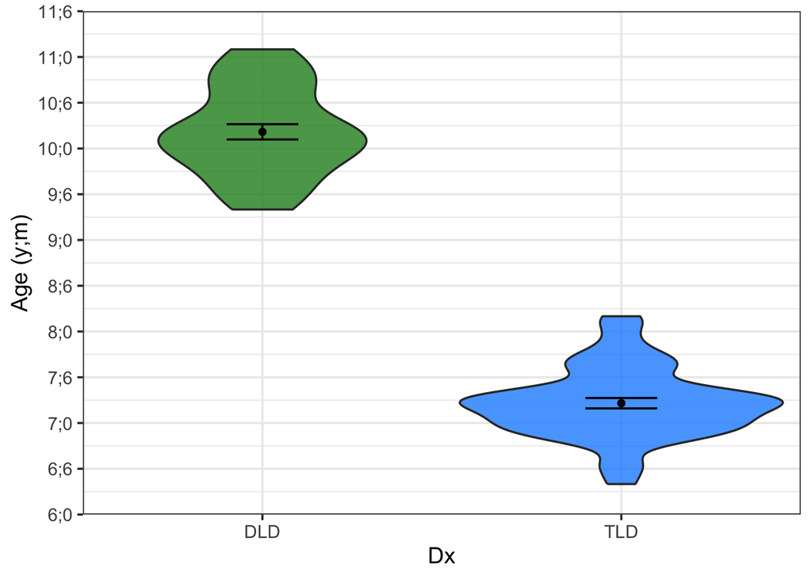

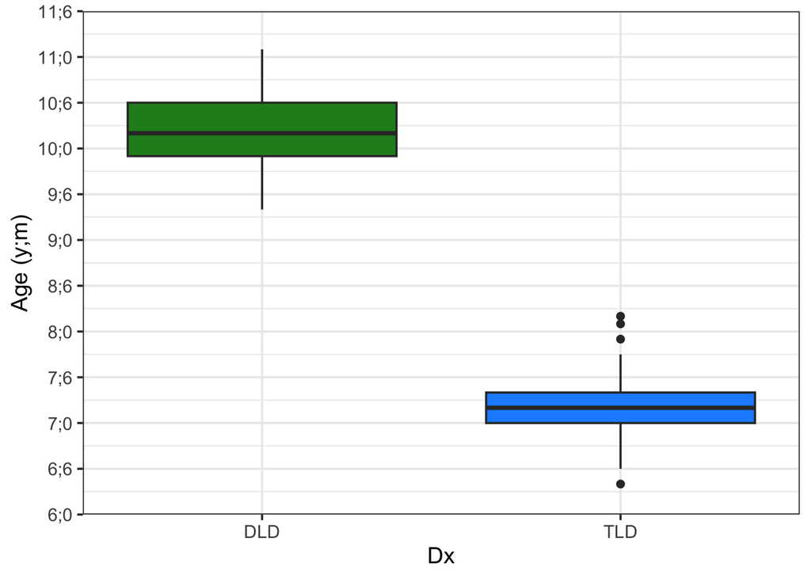

| Dx | N | Age | Age.YM | SD |
| --- | --- | --- | --- | --- |
| DLD | 33 | 122.182 | 10;2 | 5.763 |
| TLD | 45 | 86.600 | 7;2 | 4.580 |

#### Subset

Here are the average ages for children with Vocab scores:

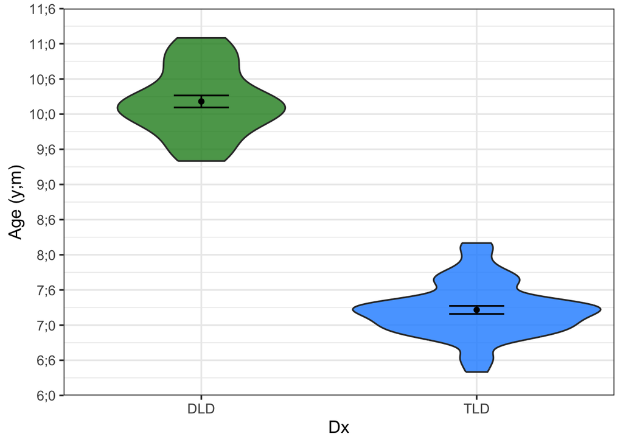

| Dx | N | Age | Age.YM | SD |
| --- | --- | --- | --- | --- |
| DLD | 31 | 122.161 | 10;2 | 5.71 |
| TLD | 45 | 86.600 | 7;2 | 4.58 |

### Vocabulary

Here are the uncorrected standard scores on the NIH Picture Vocabulary Test from year 1 for children in the TLD group and from year 4 for children in the DLD group.

These standard scores (M = 100; SD = 15) represent an individual’s performance compared to the average U.S. population - that is they are not adjusted based on the individual’s age, gender, race/ethnicity, or level of education. This is necessary to make cross-age comparisons between 7-year-old children with TLD and 10-year-old children with DLD.

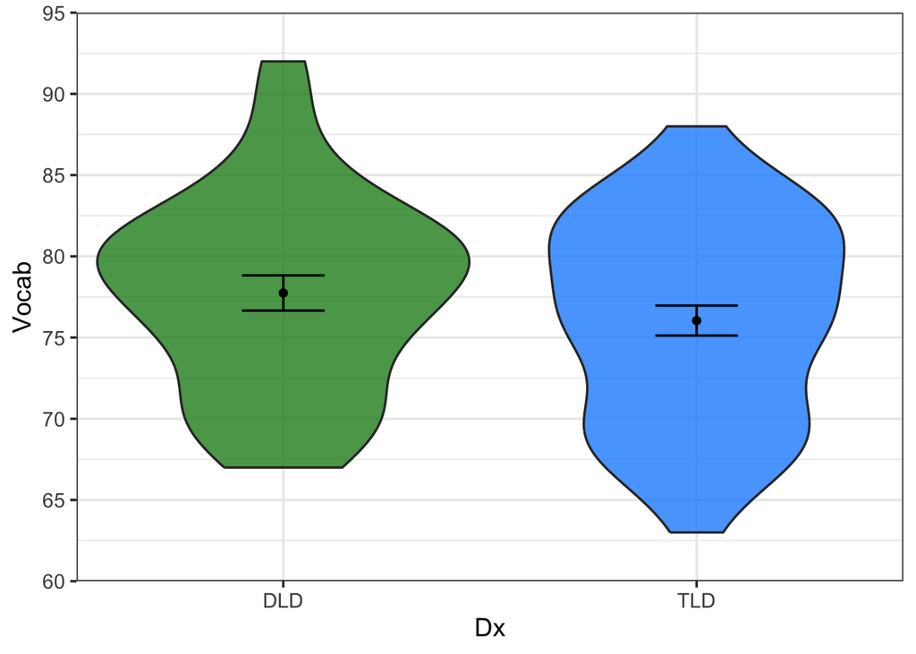

| Dx | N | Vocab | SD |
| --- | --- | --- | --- |
| DLD | 31 | 77.742 | 6.033 |
| TLD | 45 | 76.044 | 6.194 |

```
##
## Call:
## lm(formula = Vocab ~ Dx, data = stat)
##
## Residuals:
##      Min       1Q   Median       3Q      Max
## -13.0444  -5.7419   0.1068   4.0312  14.2581
##
## Coefficients:
##             Estimate Std. Error t value            Pr(>|t|)
## (Intercept)  76.8932     0.7153 107.499 <0.0000000000000002 ***
## Dx           -1.6975     1.4306  -1.187               0.239
## ---
## Signif. codes:  0 '***' 0.001 '**' 0.01 '*' 0.05 '.' 0.1 ' ' 1
##
## Residual standard error: 6.129 on 74 degrees of freedom
## Multiple R-squared:  0.01867,    Adjusted R-squared:  0.00541
## F-statistic: 1.408 on 1 and 74 DF,  p-value: 0.2392
```

The effect of vocabulary was not significant, *b* = -1.7, *t*(74) = -1.19, *p* = .239. Children in the TLD group (n = 45) had similar vocabulary scores (*M* = 76.04, *SD* = 6.19) than children in the DLD group (n = 31, *M* = 77.74, *SD* = 6.03).

### NWR

Here are the proportion of correct phonemes produced in the Nonword repetition task from year 1 for children in the TLD group and from year 4 for children in the DLD group.

#### Full

Including every child with a NWR score:

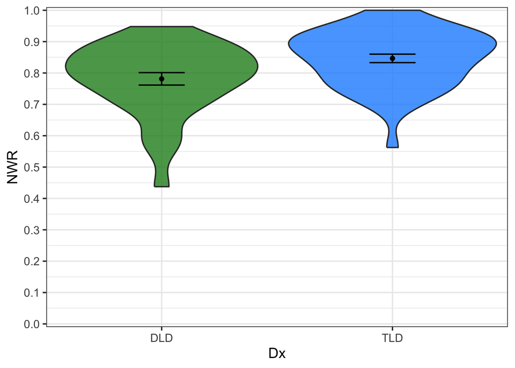

| Dx | N | NWR | SD |
| --- | --- | --- | --- |
| DLD | 33 | 0.781 | 0.114 |
| TLD | 45 | 0.847 | 0.091 |

```
##
## Call:
## lm(formula = NWR ~ Dx, data = stat)
##
## Residuals:
##      Min       1Q   Median       3Q      Max
## -0.34386 -0.06461  0.01418  0.07014  0.16655
##
## Coefficients:
##             Estimate Std. Error t value            Pr(>|t|)
## (Intercept)  0.81394    0.01157  70.327 <0.0000000000000002 ***
## Dx           0.06517    0.02315   2.815              0.0062 **
## ---
## Signif. codes:  0 '***' 0.001 '**' 0.01 '*' 0.05 '.' 0.1 ' ' 1
##
## Residual standard error: 0.101 on 76 degrees of freedom
## Multiple R-squared:  0.09444,    Adjusted R-squared:  0.08252
## F-statistic: 7.926 on 1 and 76 DF,  p-value: 0.006204
```

The effect of NWR was statistically significant, *b* = 0.07, *t*(76) = 2.82, *p* = .006. Children in the TLD group (n = 45) had higher NWR accuracy (*M* = 0.85, *SD* = 0.09) than children in the DLD group (n = 33, *M* = 0.78, *SD* = 0.11).

#### Subset

Including only children with a Vocab score:

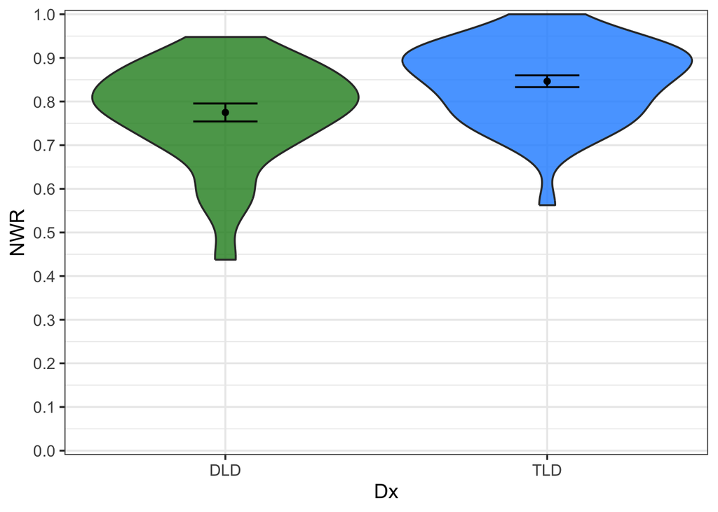

| Dx | N | NWR | SD |
| --- | --- | --- | --- |
| DLD | 31 | 0.775 | 0.114 |
| TLD | 45 | 0.847 | 0.091 |

```
##
## Call:
## lm(formula = NWR ~ Dx, data = stat)
##
## Residuals:
##      Min       1Q   Median       3Q      Max
## -0.33748 -0.06528  0.01668  0.07014  0.17293
##
## Coefficients:
##             Estimate Std. Error t value             Pr(>|t|)
## (Intercept)  0.81076    0.01177  68.863 < 0.0000000000000002 ***
## Dx           0.07154    0.02355   3.038              0.00329 **
## ---
## Signif. codes:  0 '***' 0.001 '**' 0.01 '*' 0.05 '.' 0.1 ' ' 1
##
## Residual standard error: 0.1009 on 74 degrees of freedom
## Multiple R-squared:  0.1109, Adjusted R-squared:  0.0989
## F-statistic: 9.231 on 1 and 74 DF,  p-value: 0.003286
```

The effect of NWR was statistically significant, *b* = 0.07, *t*(74) = 3.04, *p* = .003. Children in the TLD group (n = 45) had higher NWR accuracy (*M* = 0.85, *SD* = 0.09) than children in the DLD group (n = 31, *M* = 0.77, *SD* = 0.11).

## Reading

### TOSREC

Some research demonstrates that older children (e.g., 10 years old) with DLD catch up with their TLD peers in NWR performance if they have no literacy problems, while children with DLD who do have literacy problems will not catch up in NWR performance (Bishop, McDonald, Bird, & Hayiou-Thomas, 2009). There are, however, conflicting results which find that older children (8 years old) with DLD who have no literacy problems do not catch up (Vandewalle, Boets, Ghesquière & Zink, 2012).

Wagner et al. (2010) recommend a dichotomized TOSREC score, where standard scores of less than 90 are considered below average and scores of 90 or above are considered average or above average. Johnson et al. (2011) partially validate this, demonstrating that the dichotomoized TOSREC score has high sensitivity and specificity in predicting which children will subsequently not meet grade-level performance on the ISAT (Idaho Student Achievement Test)

This cut-off score, however, has not been validated for a sample of children who have DLD. We plan to conduct a sensitivity analysis and examine the impact of different cut-off scores.

Note we are missing TOSREC scores for the following11participants:

| Subject | Dx_yr1 |
| --- | --- |
| 59 | DLD |
| 68 | DLD |
| 82 | DLD |
| 97 | DLD |
| 39 | DLD |
| 63 | DLD |
| 123 | DLD |
| 42 | TLD |
| 44 | TLD |
| 8 | TLD |
| 73 | TLD |

This is mostly, because 9participants did not complete all 4 years of data collection (TOSREC was administered during the final, 4th year):

| Subject | Dx_yr1 | NWR_raw_yr1 | NWR_raw_yr2 | NWR_raw_yr3 | NWR_raw_yr4 |
| --- | --- | --- | --- | --- | --- |
| 68 | DLD | 72 | NA | NA | NA |
| 97 | DLD | 74 | NA | NA | NA |
| 39 | DLD | 78 | NA | NA | NA |
| 63 | DLD | 80 | NA | NA | NA |
| 123 | DLD | 38 | NA | NA | NA |
| 42 | TLD | 72 | NA | NA | NA |
| 44 | TLD | 54 | 82 | NA | NA |
| 8 | TLD | 88 | NA | NA | NA |
| 73 | TLD | 80 | NA | NA | NA |

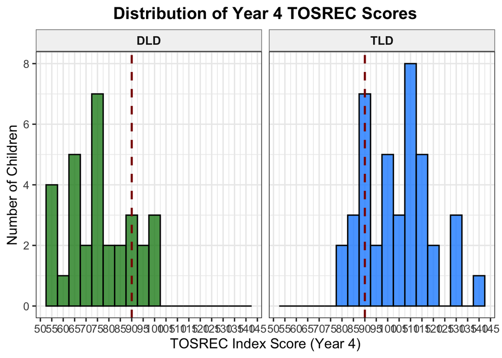

### Cut-off

Using the Wagner et al.(2010) recommend cut-off of 90, where standard scores of less than 90 are considered below average and scores of 90 or above are considered average or above average.

Here are the numbers of participants in the DLD and TLD group split by their reading ability:

| Dx_yr1 | Reading | Year | N |
| --- | --- | --- | --- |
| DLD | average | 7 | 7 |
| DLD | average | 8 | 7 |
| DLD | average | 9 | 7 |
| DLD | average | 10 | 7 |
| DLD | below | 7 | 24 |
| DLD | below | 8 | 24 |
| DLD | below | 9 | 23 |
| DLD | below | 10 | 24 |
| TLD | average | 7 | 33 |
| TLD | average | 8 | 33 |
| TLD | average | 9 | 33 |
| TLD | average | 10 | 33 |
| TLD | below | 7 | 8 |
| TLD | below | 8 | 8 |
| TLD | below | 9 | 8 |
| TLD | below | 10 | 8 |

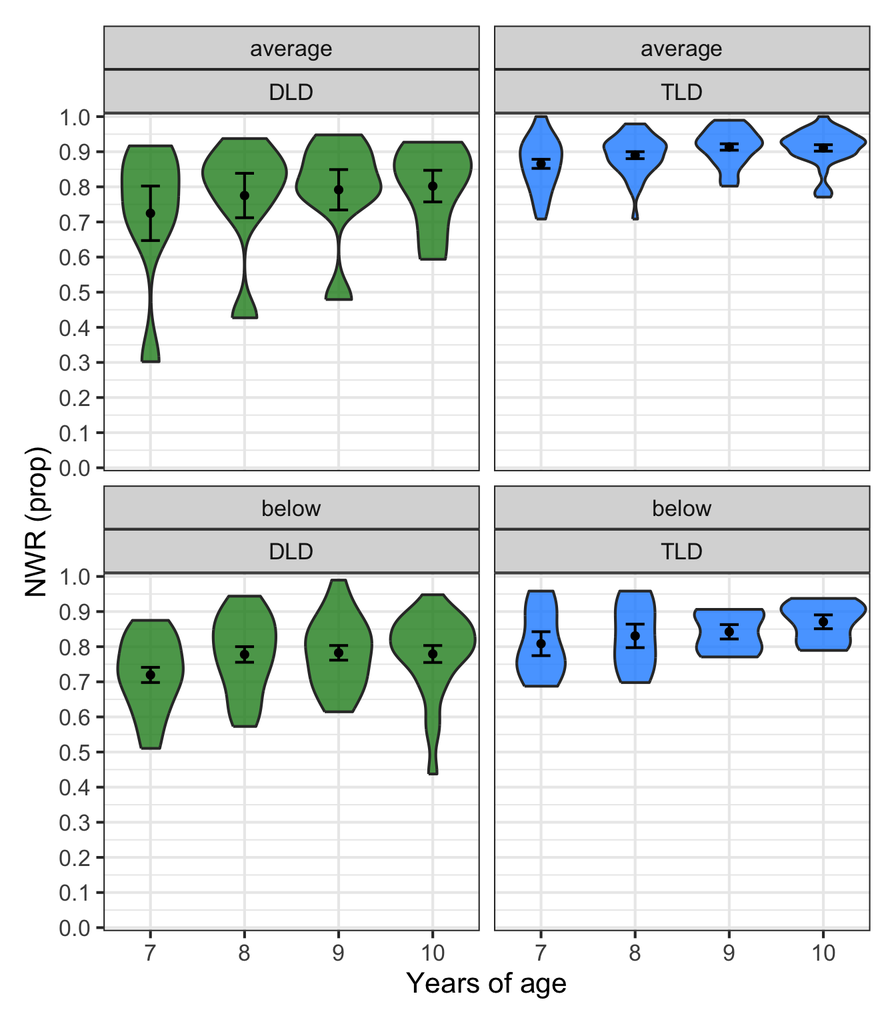

| Reading | Dx_yr1 | Year | N | NWR_prop | SD | SE |
| --- | --- | --- | --- | --- | --- | --- |
| average | DLD | 7 | 7 | 0.725 | 0.205 | 0.078 |
| average | DLD | 8 | 7 | 0.775 | 0.167 | 0.063 |
| average | DLD | 9 | 7 | 0.792 | 0.152 | 0.058 |
| average | DLD | 10 | 7 | 0.802 | 0.119 | 0.045 |
| below | DLD | 7 | 24 | 0.720 | 0.106 | 0.022 |
| below | DLD | 8 | 24 | 0.778 | 0.109 | 0.022 |
| below | DLD | 9 | 23 | 0.783 | 0.100 | 0.021 |
| below | DLD | 10 | 24 | 0.779 | 0.118 | 0.024 |
| average | TLD | 7 | 33 | 0.866 | 0.074 | 0.013 |
| average | TLD | 8 | 33 | 0.890 | 0.057 | 0.010 |
| average | TLD | 9 | 33 | 0.913 | 0.052 | 0.009 |
| average | TLD | 10 | 33 | 0.911 | 0.052 | 0.009 |
| below | TLD | 7 | 8 | 0.809 | 0.096 | 0.034 |
| below | TLD | 8 | 8 | 0.831 | 0.095 | 0.033 |
| below | TLD | 9 | 8 | 0.842 | 0.058 | 0.020 |
| below | TLD | 10 | 8 | 0.871 | 0.056 | 0.020 |

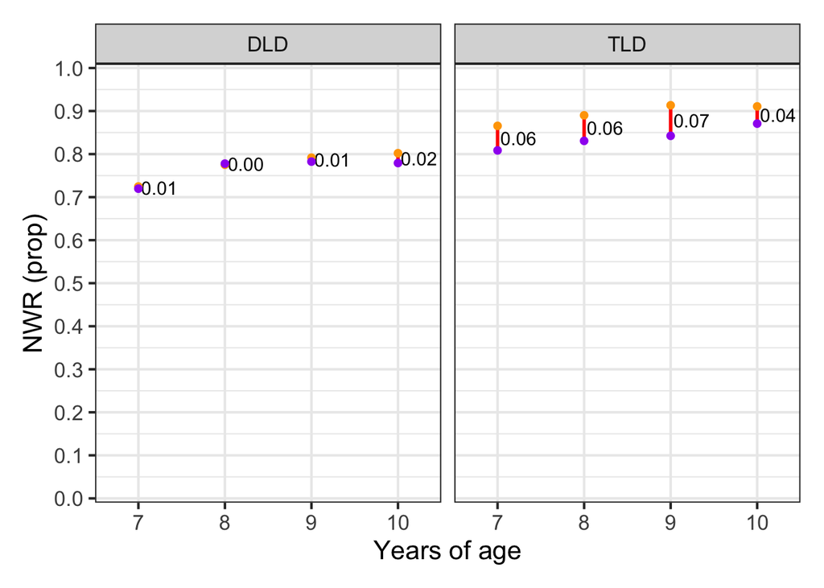

NWR accuracy for children with DLD does not vary based on their reading proficiency. For children with TLD, however, those with below average reading proficiency are less accurate in NWR than their peers with average reading proficiency. Note: this latter comparison is lacking in previous research (e.g., Bishop et al., 2009) because the control/comparison group for the DLD group was selected to *not* have dyslexia (i.e., a true TLD group). In the current project, however, the control/comparison group allowed children with reading difficulties (hence TLD rather than TD).

There is, therefore, no need to re-analyze the results because DLD with below average reading and DLD with average reading will be the same distance from the TLD group with average reading.

## Stability

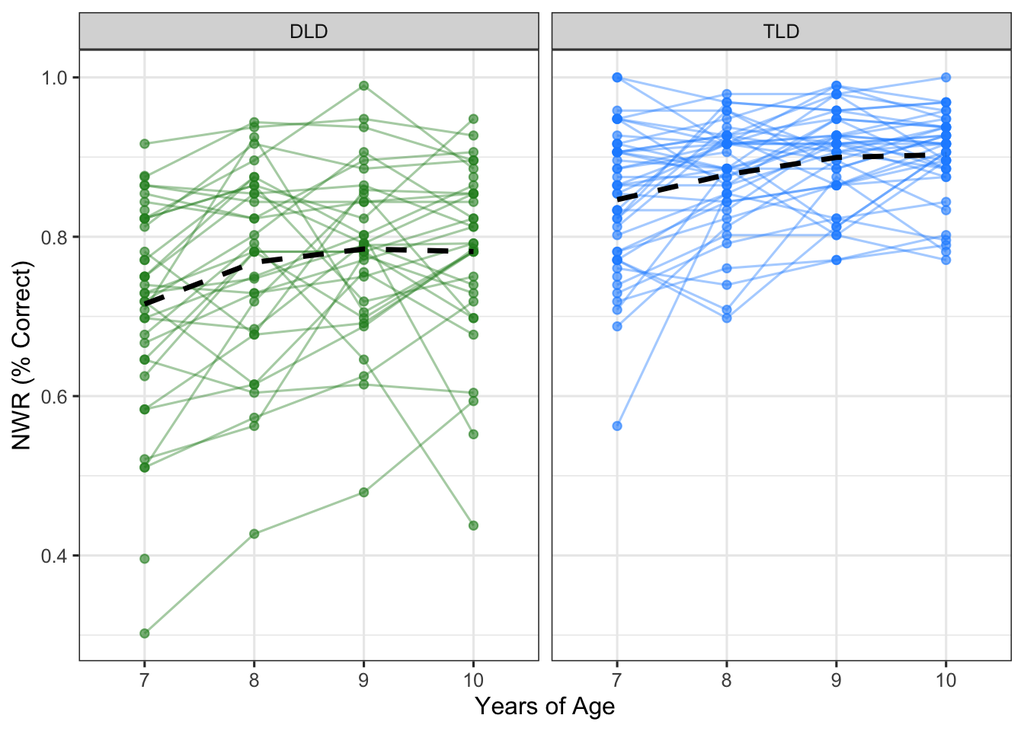

| Dx_yr1 | cor_yr7_yr8 | cor_yr8_yr9 | cor_yr9_yr10 |
| --- | --- | --- | --- |
| DLD | 0.824 | 0.688 | 0.672 |
| TLD | 0.615 | 0.654 | 0.718 |

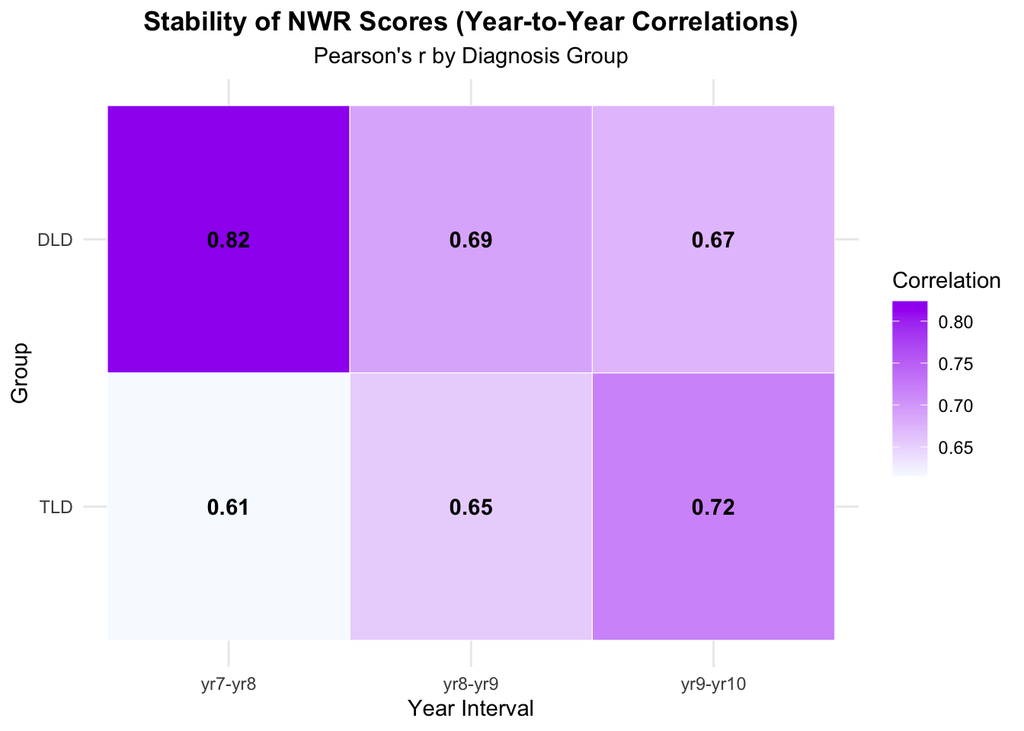

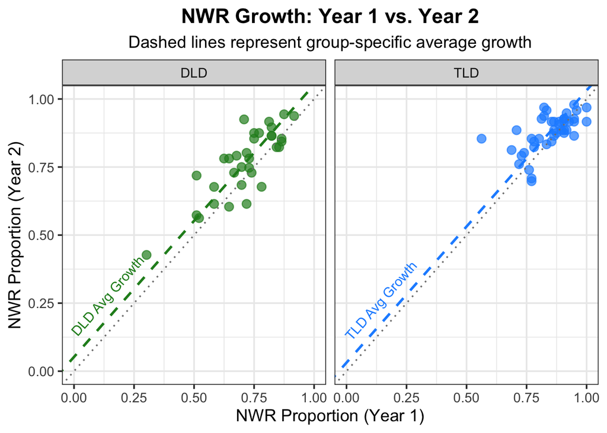

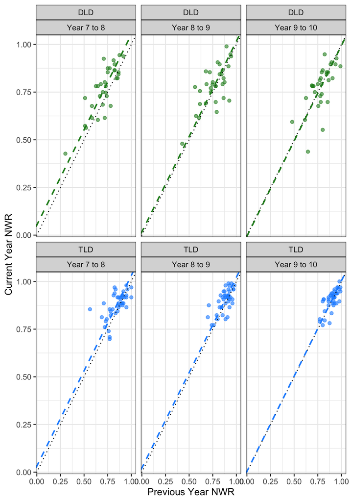

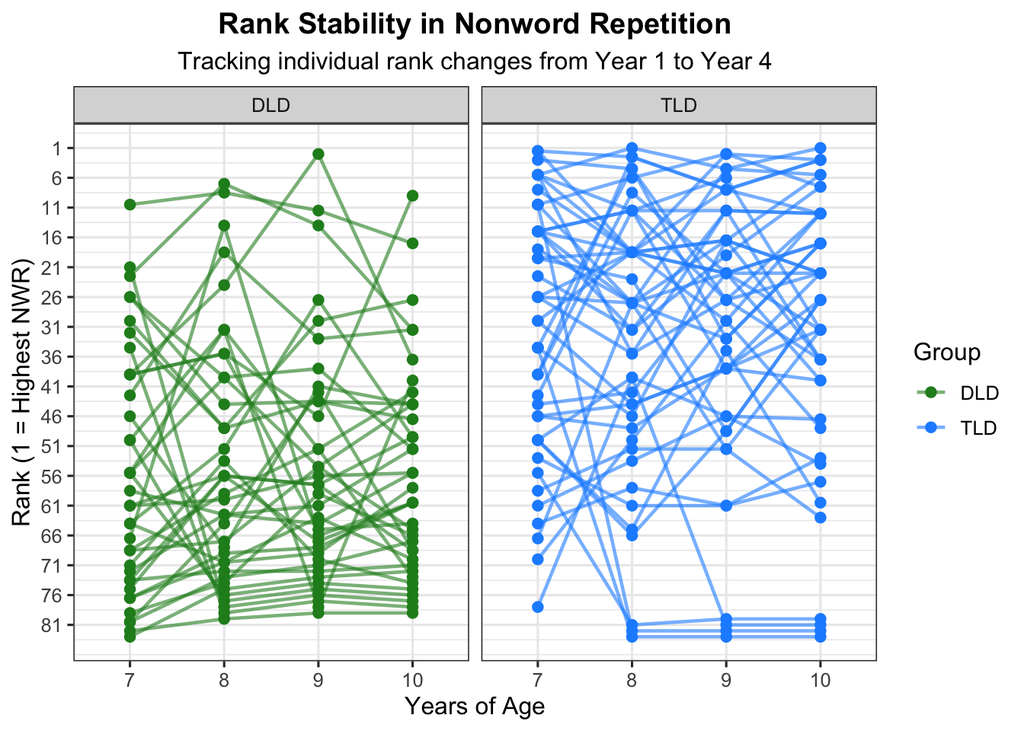

## Dx Accuracy

### across years

|  | year | threshold | sensitivity | specificity |
| --- | --- | --- | --- | --- |
| 7 | 7 | 0.755 | 0.605 | 0.844 |
| 8 | 8 | 0.828 | 0.636 | 0.810 |
| 9 | 9 | 0.862 | 0.781 | 0.805 |
| 10 | 10 | 0.870 | 0.788 | 0.829 |

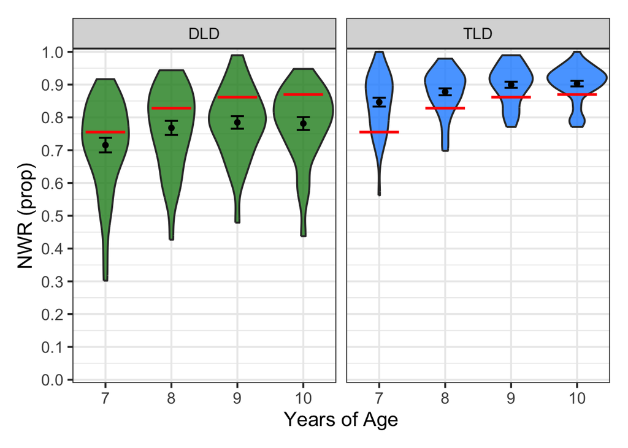

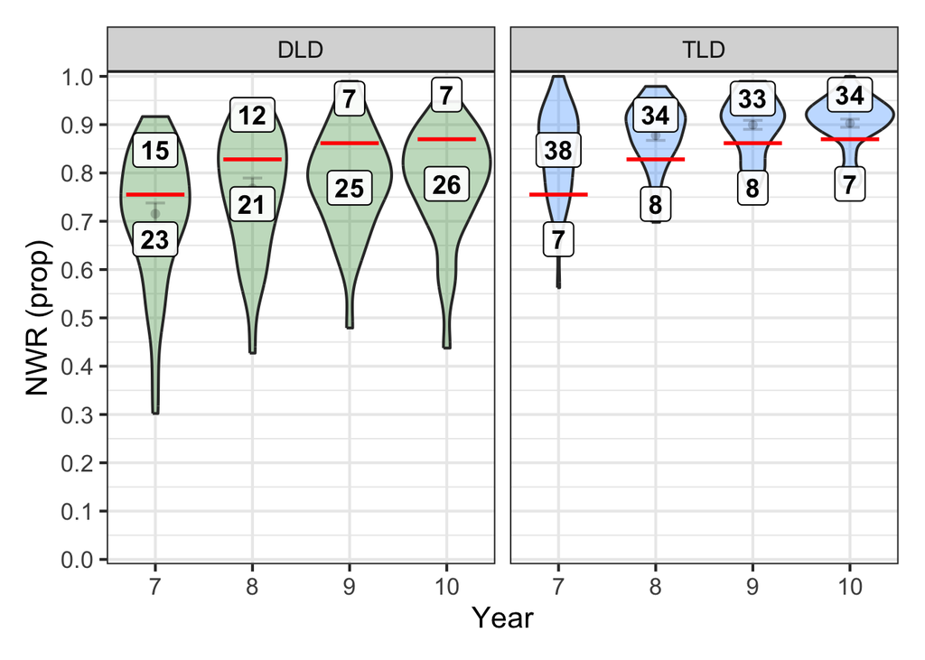

### year 7

| threshold | sensitivity | specificity |
| --- | --- | --- |
| 0.755 | 0.605 | 0.844 |

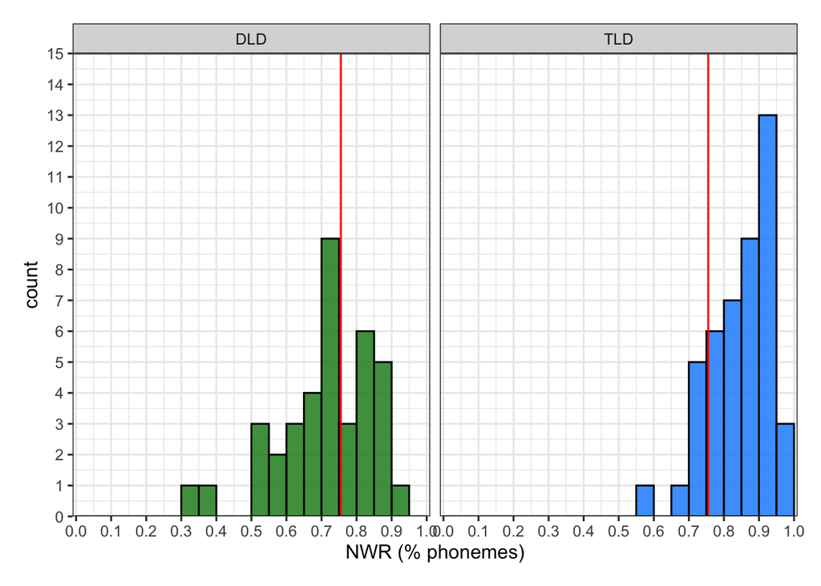

**sensitivity** is 0.605

15 in the DLD group (n=38) score above the cut-off of 0.755:

| Subject | Gender | Dx_yr1 | Year | Age_in_months | NWR_prop |
| --- | --- | --- | --- | --- | --- |
| 97 | F | DLD | 7 | 90 | 0.771 |
| 91 | M | DLD | 7 | 94 | 0.771 |
| 74 | M | DLD | 7 | 80 | 0.781 |
| 26 | M | DLD | 7 | 85 | 0.812 |
| 104 | M | DLD | 7 | 94 | 0.823 |
| 127 | M | DLD | 7 | 93 | 0.823 |
| 141 | M | DLD | 7 | 74 | 0.823 |
| 63 | M | DLD | 7 | 89 | 0.833 |
| 81 | F | DLD | 7 | 81 | 0.844 |
| 98 | M | DLD | 7 | 86 | 0.854 |
| 21 | F | DLD | 7 | 86 | 0.865 |
| 139 | M | DLD | 7 | 94 | 0.865 |
| 93 | M | DLD | 7 | 85 | 0.875 |
| 39 | M | DLD | 7 | 95 | 0.876 |
| 55 | F | DLD | 7 | 86 | 0.917 |

**specificity** is 0.844

7 in the TLD group (n=45) score below the cut-off of 0.755:

| Subject | Gender | Dx_yr1 | Year | Age_in_months | NWR_prop |
| --- | --- | --- | --- | --- | --- |
| 44 | F | TLD | 7 | 84 | 0.562 |
| 3 | F | TLD | 7 | 82 | 0.688 |
| 19 | F | TLD | 7 | 92 | 0.708 |
| 18 | M | TLD | 7 | 85 | 0.719 |
| 35 | M | TLD | 7 | 82 | 0.729 |
| 77 | M | TLD | 7 | 83 | 0.740 |
| 42 | F | TLD | 7 | 85 | 0.750 |

### year 8

| threshold | sensitivity | specificity |
| --- | --- | --- |
| 0.828 | 0.636 | 0.81 |

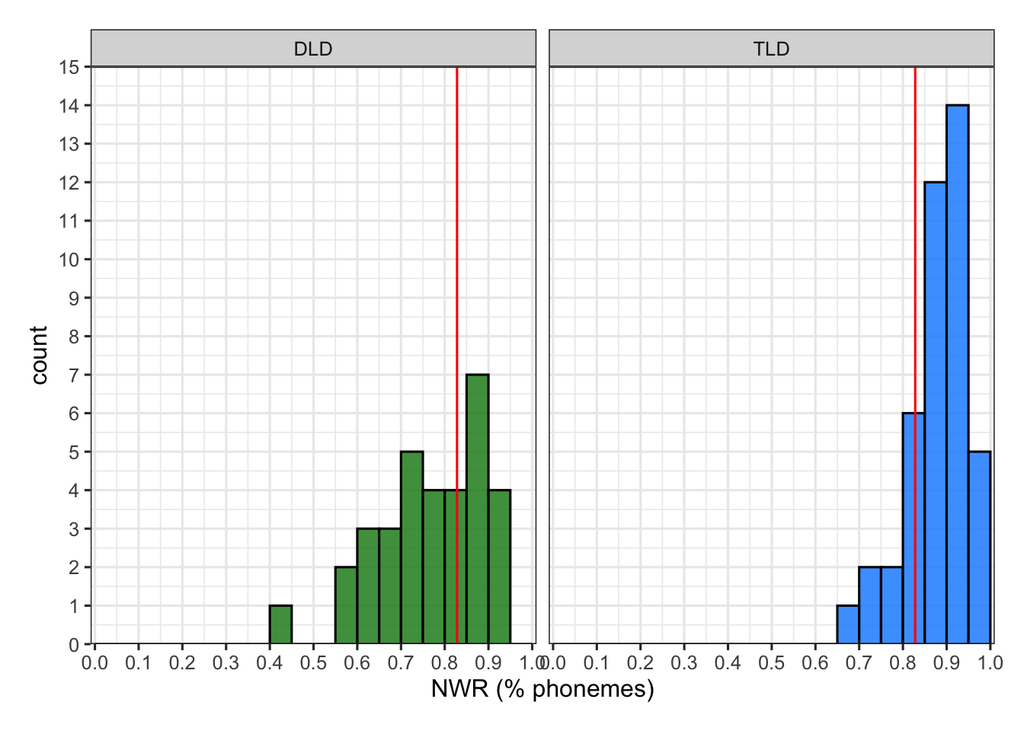

**sensitivity** is 0.636

| Subject | Gender | Dx_yr1 | Year | Age_in_months | NWR_prop |
| --- | --- | --- | --- | --- | --- |
| 139 | M | DLD | 8 | 105 | 0.844 |
| 21 | F | DLD | 8 | 98 | 0.854 |
| 72 | M | DLD | 8 | 91 | 0.854 |
| 127 | M | DLD | 8 | 105 | 0.865 |
| 141 | M | DLD | 8 | 87 | 0.865 |
| 75 | M | DLD | 8 | 96 | 0.875 |
| 91 | M | DLD | 8 | 109 | 0.875 |
| 104 | M | DLD | 8 | 107 | 0.896 |
| 26 | M | DLD | 8 | 97 | 0.917 |
| 103 | F | DLD | 8 | 111 | 0.925 |
| 55 | F | DLD | 8 | 99 | 0.938 |
| 93 | M | DLD | 8 | 97 | 0.944 |

**specificity** is 0.81

| Subject | Gender | Dx_yr1 | Year | Age_in_months | NWR_prop |
| --- | --- | --- | --- | --- | --- |
| 80 | M | TLD | 8 | 90 | 0.698 |
| 25 | F | TLD | 8 | 94 | 0.708 |
| 27 | F | TLD | 8 | 103 | 0.740 |
| 18 | M | TLD | 8 | 98 | 0.760 |
| 35 | M | TLD | 8 | 95 | 0.792 |
| 77 | M | TLD | 8 | 94 | 0.802 |
| 3 | F | TLD | 8 | 94 | 0.812 |
| 32 | M | TLD | 8 | 104 | 0.823 |

### year 9

| threshold | sensitivity | specificity |
| --- | --- | --- |
| 0.862 | 0.781 | 0.805 |

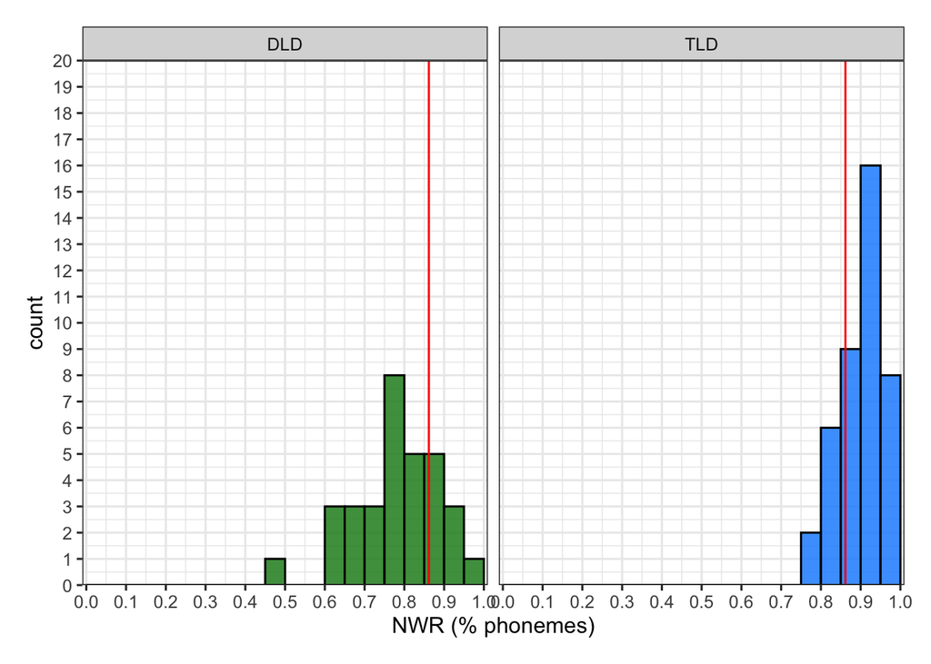

**sensitivity** is 0.781

| Subject | Gender | Dx_yr1 | Year | Age_in_months | NWR_prop |
| --- | --- | --- | --- | --- | --- |
| 21 | F | DLD | 9 | 111 | 0.865 |
| 26 | M | DLD | 9 | 112 | 0.885 |
| 81 | F | DLD | 9 | 105 | 0.896 |
| 13 | F | DLD | 9 | 111 | 0.906 |
| 93 | M | DLD | 9 | 110 | 0.938 |
| 55 | F | DLD | 9 | 110 | 0.948 |
| 104 | M | DLD | 9 | 119 | 0.990 |

**specificity** is 0.805

| Subject | Gender | Dx_yr1 | Year | Age_in_months | NWR_prop |
| --- | --- | --- | --- | --- | --- |
| 27 | F | TLD | 9 | 115 | 0.771 |
| 18 | M | TLD | 9 | 110 | 0.771 |
| 19 | F | TLD | 9 | 117 | 0.802 |
| 77 | M | TLD | 9 | 106 | 0.802 |
| 92 | F | TLD | 9 | 108 | 0.812 |
| 80 | M | TLD | 9 | 138 | 0.812 |
| 31 | F | TLD | 9 | 110 | 0.823 |
| 35 | M | TLD | 9 | 107 | 0.823 |

### year 10

| threshold | sensitivity | specificity |
| --- | --- | --- |
| 0.87 | 0.788 | 0.829 |

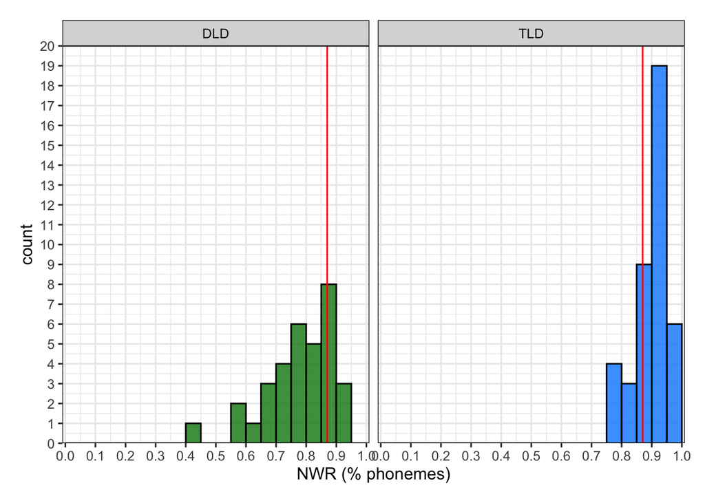

**sensitivity** is 0.788

| Subject | Gender | Dx_yr1 | Year | Age_in_months | NWR_prop |
| --- | --- | --- | --- | --- | --- |
| 91 | M | DLD | 10 | 126 | 0.875 |
| 104 | M | DLD | 10 | 132 | 0.885 |
| 26 | M | DLD | 10 | 121 | 0.896 |
| 93 | M | DLD | 10 | 122 | 0.896 |
| 81 | F | DLD | 10 | 116 | 0.906 |
| 55 | F | DLD | 10 | 123 | 0.927 |
| 141 | M | DLD | 10 | 112 | 0.948 |

**specificity** is 0.829

| Subject | Gender | Dx_yr1 | Year | Age_in_months | NWR_prop |
| --- | --- | --- | --- | --- | --- |
| 77 | M | TLD | 10 | 118 | 0.771 |
| 25 | F | TLD | 10 | 118 | 0.781 |
| 27 | F | TLD | 10 | 127 | 0.789 |
| 35 | M | TLD | 10 | 119 | 0.796 |
| 18 | M | TLD | 10 | 121 | 0.802 |
| 3 | F | TLD | 10 | 118 | 0.833 |
| 31 | F | TLD | 10 | 119 | 0.844 |